# MPLADS Analysis

2020-06-18

### Document History

Original Publish Date: 18 June, 2020

Updated on: 30 September, 2021

# Summary stats

This mplads data is for the 14th and 15the Loksabha which commenced on 20004 and 2009 respectively. We matched it with Uttar Pradesh MPs for the same years.

Main variables : Type of project and the cost incurred. Main categories of type of projects are Road, Electricity, Education, Construction, Water, Others, Sanitation

### Two type of comparisons

#### Family v/s Non-family

MPLADS 2004:2009 UP

| Entity | Count of projects | Avg. # of projects in a PC | Avg. cost of a project | Avg. # of weeks to sanction a project |
| --- | --- | --- | --- | --- |
| Family | 13395 | 429 | 317783 | 10 |
| Non-family | 19782 | 319 | 350653 | 10 |

#### Stable v/s non-family

MPLADS 2009 - UP

| Entity | Count of projects | Avg. # of projects in a PC | Avg. cost of a project | Avg. # of weeks to sanction a project |
| --- | --- | --- | --- | --- |
| Non-Family | 7655 | 269 | 13 | 2 |
| Stable Family | 6476 | 553 | 12 | 2 |

### Projects

**Question** - Is there any difference in the project choices of family politicians?

This table shows the composition of the category of the projects they choose work on.

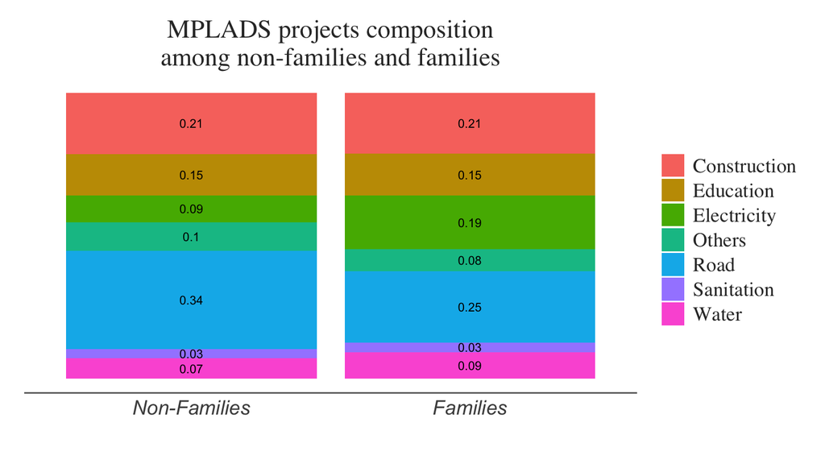

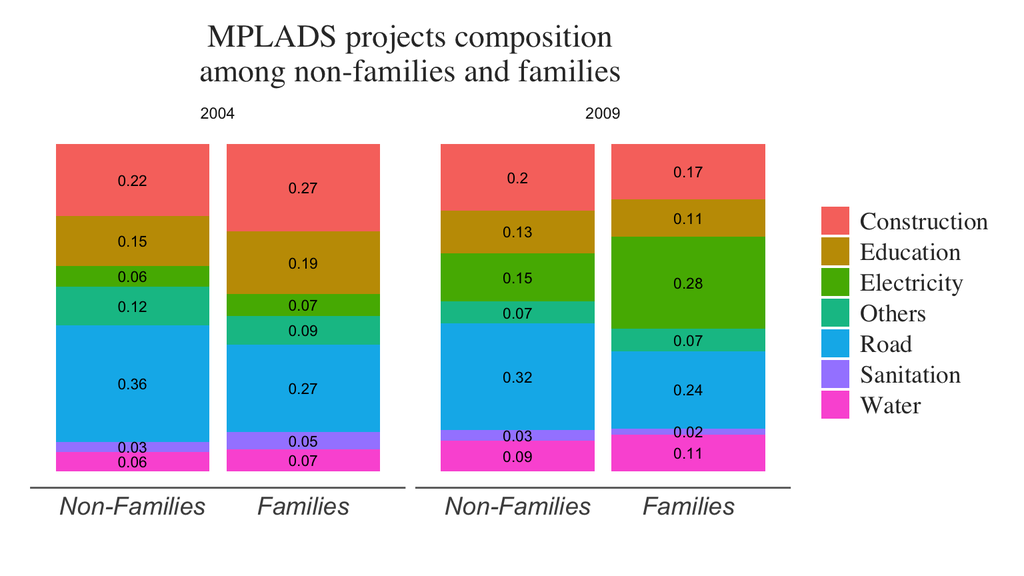

This chart shows the average number of projects of each categories according to the family type.

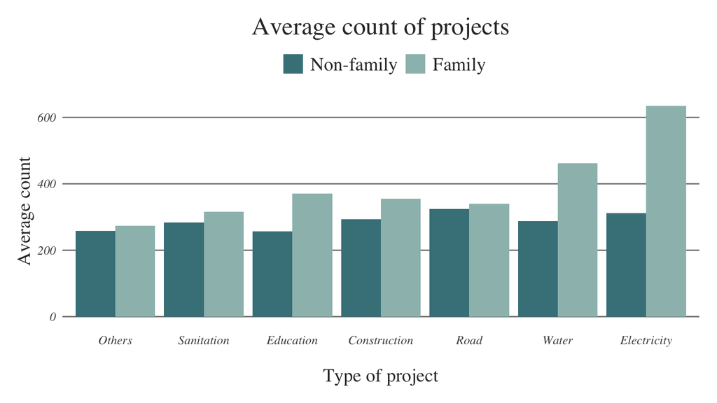

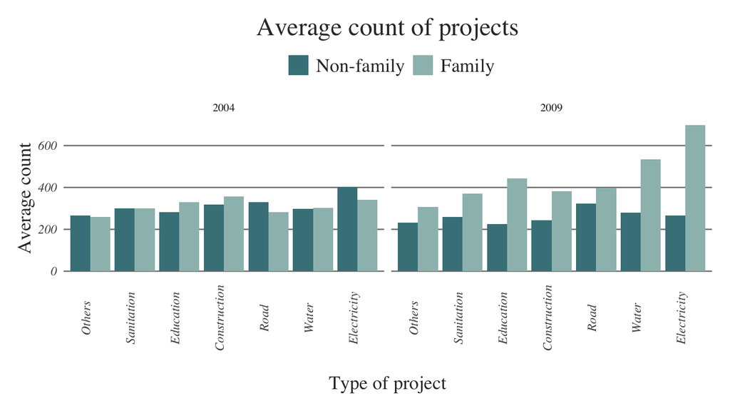

### Expenditure

**Question** - Is there any difference in the spending patterns of family politicians?

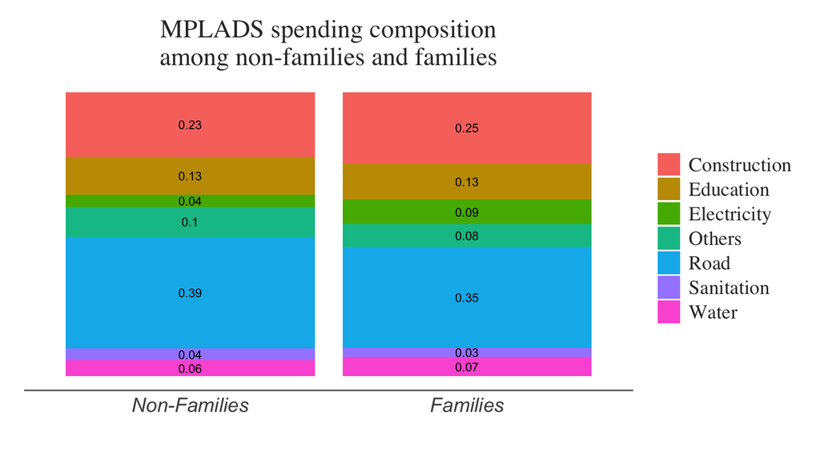

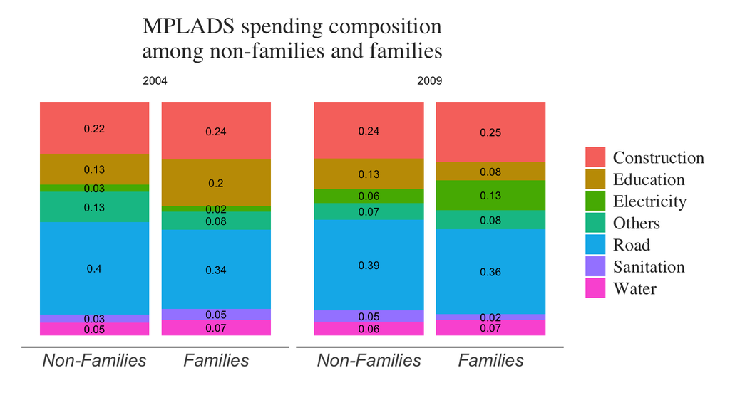

## Cost per project

**Question** : What’s the average cost of a project for each categories?

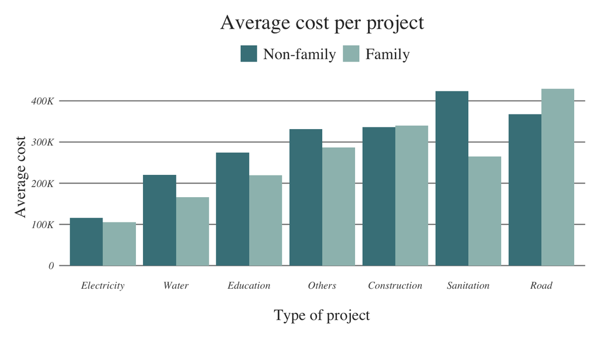

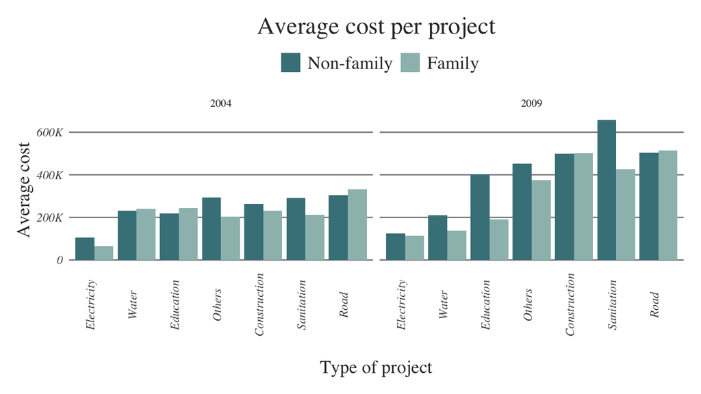

### cost categories

We categorised the projects into three depending upon the cost of the project:

Categories:

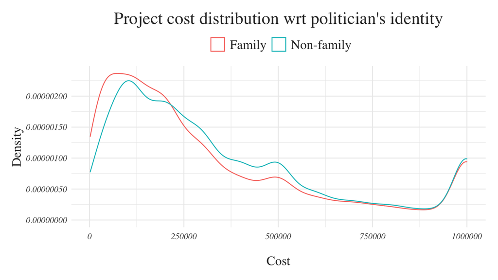

Project cost categories wrt politician’s identity

| Cost Categry | Politicians Identity | Proportion of projects |
| --- | --- | --- |
| Low | Family | 0.49 |
| Low | Non-family | 0.40 |
| Medium | Family | 0.30 |
| Medium | Non-family | 0.37 |
| High | Family | 0.21 |
| High | Non-family | 0.23 |